# Gaussian Mixture Model by Expectation-Maximization

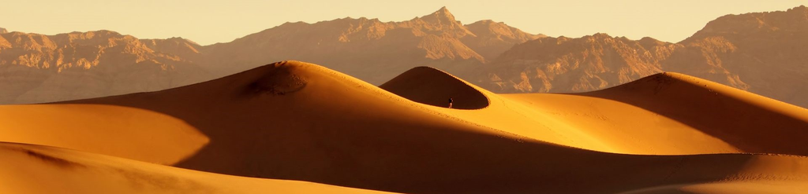

Like sand dunes shifting in the wind ...

== document setup ==

## Synopsis

**Terms**

- **Gaussian Mixture Model:** A set of Gaussian functions, each one associated with a cluster.
- **Expectation-Maximization:** A method to estimate a Gaussian mixture model.
- **Gaussian Mixtue Model Estimation by Expectation-Maximization** is a cluster model construction method.

## Exposition

### At a Glance

#### Data

| x1 |
| --- |
| 2.0 |
| 2.5 |
| 4.0 |
| 6.5 |
| 8.0 |
| 9.0 |
| 10.0 |
| 10.5 |

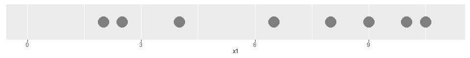

#### Initialize

Each cluster is associated with its own Gaussian function defined by a size, mean, and standard deviation.

**Initialization**

| cluster | size | mean | sd |
| --- | --- | --- | --- |
| A | 0.5 | 9 | 1 |
| B | 0.5 | 10 | 1 |

#### Update Partial Cluster Assignments

| x1 | g.A | g.B | weight.A | weight.B |
| --- | --- | --- | --- | --- |
| 2.0 | 0.00000000000456736 | 2.526136e-15 | 0.9994472 | 0.0005527786 |
| 2.5 | 0.00000000013347783 | 1.217160e-13 | 0.9990889 | 0.0009110512 |
| 4.0 | 0.00000074335975737 | 3.037941e-09 | 0.9959299 | 0.0040701377 |
| 6.5 | 0.00876415024678427 | 4.363413e-04 | 0.9525741 | 0.0474258732 |
| 8.0 | 0.12098536225957168 | 2.699548e-02 | 0.8175745 | 0.1824255238 |
| 9.0 | 0.19947114020071635 | 1.209854e-01 | 0.6224593 | 0.3775406688 |
| 10.0 | 0.12098536225957168 | 1.994711e-01 | 0.3775407 | 0.6224593312 |
| 10.5 | 0.06475879783294587 | 1.760327e-01 | 0.2689414 | 0.7310585786 |

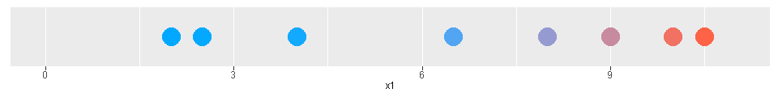

#### Update Gaussian Functions

To find more satisfactory Gaussian functions, adjust the Gaussian functions according to the partial cluster assignments.

[output not shown]

| x1 | g.A | g.B | weight.A | weight.B |
| --- | --- | --- | --- | --- |
| 2.0 | 0.0656014191 | 0.0000000000002728804 | 1.000000000 | 0.000000000004159672 |
| 2.5 | 0.0820019650 | 0.0000000000097037649 | 1.000000000 | 0.000000000118335760 |
| 4.0 | 0.1066275164 | 0.0000000971680869243 | 0.999999089 | 0.000000911284457027 |
| 6.5 | 0.0425582941 | 0.0030252467726058926 | 0.933632914 | 0.066367085949616142 |
| 8.0 | 0.0108711898 | 0.0744838305723369981 | 0.127364386 | 0.872635613601134508 |
| 9.0 | 0.0031181640 | 0.1802999800777327355 | 0.017000303 | 0.982999697091273994 |
| 10.0 | 0.0006819127 | 0.1603426248640237028 | 0.004234837 | 0.995765162577665008 |
| 10.5 | 0.0002880525 | 0.1038712856450726973 | 0.002765499 | 0.997234501005452856 |

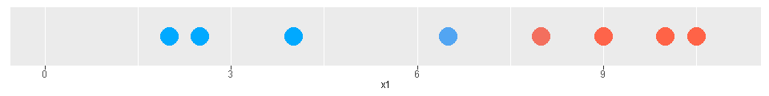

#### Commit Cluster Assignments

Assign each observation to the cluster for which it has that highest cluster assignment weight.

| x1 | g.A | g.B | weight.A | weight.B | cluster |
| --- | --- | --- | --- | --- | --- |
| 2.0 | 0.0656014191 | 0.0000000000002728804 | 1.000000000 | 0.000000000004159672 | A |
| 2.5 | 0.0820019650 | 0.0000000000097037649 | 1.000000000 | 0.000000000118335760 | A |
| 4.0 | 0.1066275164 | 0.0000000971680869243 | 0.999999089 | 0.000000911284457027 | A |
| 6.5 | 0.0425582941 | 0.0030252467726058926 | 0.933632914 | 0.066367085949616142 | A |
| 8.0 | 0.0108711898 | 0.0744838305723369981 | 0.127364386 | 0.872635613601134508 | B |
| 9.0 | 0.0031181640 | 0.1802999800777327355 | 0.017000303 | 0.982999697091273994 | B |
| 10.0 | 0.0006819127 | 0.1603426248640237028 | 0.004234837 | 0.995765162577665008 | B |
| 10.5 | 0.0002880525 | 0.1038712856450726973 | 0.002765499 | 0.997234501005452856 | B |

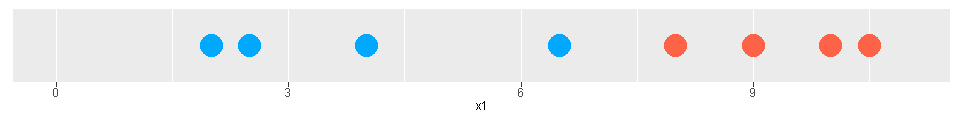

### Expectation-Maximization for One Variable, Two Clusters

#### Expectation Step

Update weights (partial cluster assignments) like this:

$ \text{For class} \, A \text{:} \quad w_{Ai} = \large\frac{g_A(x_i)}{g_A(x_i) \, + \, g_B(x_i)} $

$ \text{For class} \, B \text{:} \quad w_{Bi} = \large\frac{g_B(x_i)}{g_A(x_i) \, + \, g_B(x_i)} $

where ...

- $w_{Ai}$ is the weight of the $i^{th}$ observation, with respect to class $A$
- $w_{Bi}$ is the weight of the $i^{th}$ observation, with respect to class $B$
- $x$ is the distribution of observation values and $x_i$ is the $i^{th}$ value
- $g_A$ is the Gaussian function for class $A$
- $g_B$ is the Gaussian function for class $B$

#### Maximization Step

where ...

- $s_A$ is the size of the new gaussian function for class $A$
- $s_B$ is the size of the new gaussian function for class $B$
- $\mu_A$ is the mean of the new gaussian function for class $A$
- $\mu_B$ is the mean of the new gaussian function for class $B$
- $\sigma_A$ is the standard deviation of the new gaussian function for class $A$
- $\sigma_B$ is the standard deviation of the new gaussian function for class $B$
- $x$ is the distribution of observation values and $x_i$ is the $i^{th}$ value
- $w_{Ai}$ is the weight (partial assignment) of the $i^{th}$ observation to class $A$
- $w_{Bi}$ is the weight (partial assignment) of the $i^{th}$ observation to class $B$
- $n$ is the number of observations

### Example: One Variable, Two Clusters

#### Data

| x1 |
| --- |
| 2.0 |
| 2.5 |
| 4.0 |
| 6.5 |
| 8.0 |
| 9.0 |
| 10.0 |
| 10.5 |

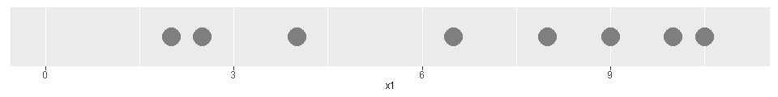

#### Initialize

**Initialization**

| cluster | size | mean | sd |
| --- | --- | --- | --- |
| A | 0.5 | 9 | 1 |
| B | 0.5 | 10 | 1 |

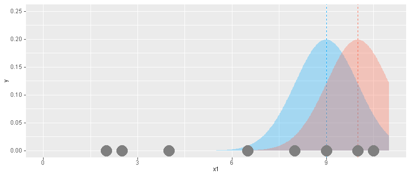

| x1 | g.A | g.B | weight.A | weight.B |
| --- | --- | --- | --- | --- |
| 8 | 0.1209854 | 0.02699548 | 0.8175745 | 0.1824255 |

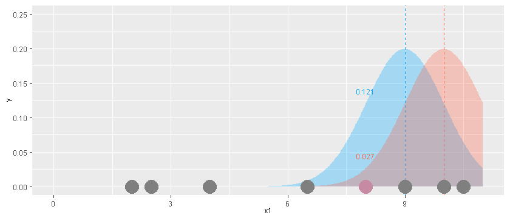

| x1 | g.A | g.B | weight.A | weight.B |
| --- | --- | --- | --- | --- |
| 2.0 | 0.00000000000456736 | 2.526136e-15 | 0.9994472 | 0.0005527786 |
| 2.5 | 0.00000000013347783 | 1.217160e-13 | 0.9990889 | 0.0009110512 |
| 4.0 | 0.00000074335975737 | 3.037941e-09 | 0.9959299 | 0.0040701377 |
| 6.5 | 0.00876415024678427 | 4.363413e-04 | 0.9525741 | 0.0474258732 |
| 8.0 | 0.12098536225957168 | 2.699548e-02 | 0.8175745 | 0.1824255238 |
| 9.0 | 0.19947114020071635 | 1.209854e-01 | 0.6224593 | 0.3775406688 |
| 10.0 | 0.12098536225957168 | 1.994711e-01 | 0.3775407 | 0.6224593312 |
| 10.5 | 0.06475879783294587 | 1.760327e-01 | 0.2689414 | 0.7310585786 |

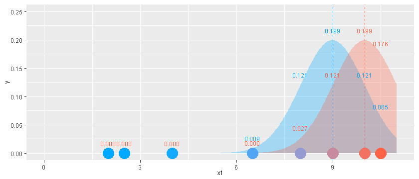

#### Iterate

Use expectation-maximization to iteratively update partial cluster assignments & Guassian functions.

**Iteration 1**

| cluster | size | mean | sd |
| --- | --- | --- | --- |
| A | 0.7541945 | 5.538042 | 2.9222384 |
| B | 0.2458055 | 9.705799 | 0.9916958 |

| x1 | g.A | g.B | weight.A | weight.B |
| --- | --- | --- | --- | --- |
| 2.0 | 0.04947305 | 7.659781e-15 | 1.0000000 | 0.0000000000001548274 |
| 2.5 | 0.05997622 | 3.391957e-13 | 1.0000000 | 0.0000000000056555025 |
| 4.0 | 0.08964467 | 6.408475e-09 | 0.9999999 | 0.0000000714875130352 |
| 6.5 | 0.09753199 | 5.320317e-04 | 0.9945746 | 0.0054253508617753783 |
| 8.0 | 0.07220194 | 2.252436e-02 | 0.7622164 | 0.2377836353311807149 |
| 9.0 | 0.05104013 | 7.675938e-02 | 0.3993766 | 0.6006234137525415795 |
| 10.0 | 0.03209353 | 9.462636e-02 | 0.2532636 | 0.7467364495725239415 |
| 10.5 | 0.02435560 | 7.175516e-02 | 0.2534118 | 0.7465882053688845943 |

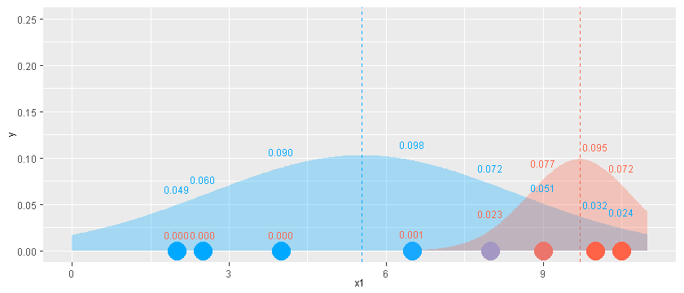

**Iteration 100**

| cluster | size | mean | sd |
| --- | --- | --- | --- |
| A | 0.373673 | 2.829513 | 0.8492576 |
| B | 0.626327 | 8.789637 | 1.4511605 |

| x1 | g.A | g.B | weight.A | weight.B |
| --- | --- | --- | --- | --- |
| 2.0 | 1.089418e-01 | 0.000003037119 | 9.999721e-01 | 0.00002787758 |
| 2.5 | 1.628066e-01 | 0.000014348253 | 9.999119e-01 | 0.00008812292 |
| 4.0 | 6.790111e-02 | 0.000742103388 | 9.891890e-01 | 0.01081102272 |
| 6.5 | 1.542162e-05 | 0.049592914073 | 3.108676e-04 | 0.99968913242 |
| 8.0 | 1.568299e-09 | 0.148491129540 | 1.056157e-08 | 0.99999998944 |
| 9.0 | 6.038643e-13 | 0.170385511997 | 3.544106e-12 | 1.00000000000 |
| 10.0 | 5.811641e-17 | 0.121600138015 | 4.779304e-16 | 1.00000000000 |
| 10.5 | 3.389782e-19 | 0.085970259819 | 3.942971e-18 | 1.00000000000 |

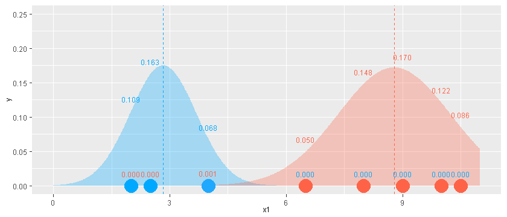

#### Commit Cluster Assignments

| x1 | g.A | g.B | weight.A | weight.B | cluster |
| --- | --- | --- | --- | --- | --- |
| 2.0 | 1.089418e-01 | 0.000003037119 | 9.999721e-01 | 0.00002787758 | A |
| 2.5 | 1.628066e-01 | 0.000014348253 | 9.999119e-01 | 0.00008812292 | A |
| 4.0 | 6.790111e-02 | 0.000742103388 | 9.891890e-01 | 0.01081102272 | A |
| 6.5 | 1.542162e-05 | 0.049592914073 | 3.108676e-04 | 0.99968913242 | B |
| 8.0 | 1.568299e-09 | 0.148491129540 | 1.056157e-08 | 0.99999998944 | B |
| 9.0 | 6.038643e-13 | 0.170385511997 | 3.544106e-12 | 1.00000000000 | B |
| 10.0 | 5.811641e-17 | 0.121600138015 | 4.779304e-16 | 1.00000000000 | B |
| 10.5 | 3.389782e-19 | 0.085970259819 | 3.942971e-18 | 1.00000000000 | B |

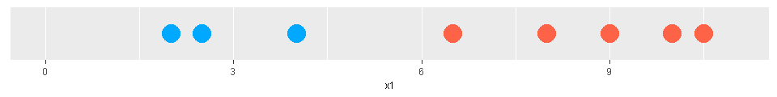

### Example: One Variable, Many Clusters - Initialization I

#### Data

| x1 |
| --- |
| 2.0 |
| 2.5 |
| 4.0 |
| 6.5 |
| 8.0 |
| 9.0 |
| 10.0 |
| 10.5 |

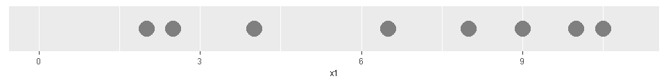

#### Initialize

**Initialization**

| class | size | mean | sd |
| --- | --- | --- | --- |
| A | 0.3333333 | 9 | 1 |
| B | 0.3333333 | 10 | 1 |
| C | 0.3333333 | 8 | 1 |

| x1 | g.A | g.B | g.C | weight.A | weight.B | weight.C |
| --- | --- | --- | --- | --- | --- | --- |
| 2.0 | 0.000000000003044907 | 0.00000000000000168409 | 0.000000002025294 | 0.001501181 | 0.0000008302798 | 0.99849799 |
| 2.5 | 0.000000000088985220 | 0.00000000000008114402 | 0.000000035899200 | 0.002472618 | 0.0000022547354 | 0.99752513 |
| 4.0 | 0.000000495573171578 | 0.00000000202529428327 | 0.000044610075255 | 0.010986449 | 0.0000448991073 | 0.98896865 |
| 6.5 | 0.005842766831189512 | 0.00029089423168192000 | 0.043172531888631 | 0.118499655 | 0.0058997504019 | 0.87560060 |
| 8.0 | 0.080656908173047784 | 0.01799698883772934965 | 0.132980760133811 | 0.348207428 | 0.0776955791486 | 0.57409699 |
| 9.0 | 0.132980760133810882 | 0.08065690817304778382 | 0.080656908173048 | 0.451862762 | 0.2740686190612 | 0.27406862 |
| 10.0 | 0.080656908173047784 | 0.13298076013381088245 | 0.017996988837729 | 0.348207428 | 0.5740969929677 | 0.07769558 |
| 10.5 | 0.043172531888630572 | 0.11735510892143315165 | 0.005842766831190 | 0.259496460 | 0.7053845126982 | 0.03511903 |

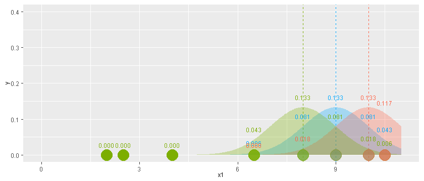

#### Iterate

Use expectation-maximization to iteratively update partial cluster assignments & Guassian functions.

**Iteration 1**

| cluster | size | mean | sd |
| --- | --- | --- | --- |
| A | 0.1926542 | 9.007450 | 1.266841 |
| B | 0.2046492 | 9.940319 | 0.711772 |
| C | 0.6026966 | 4.634004 | 2.498178 |

| x1 | g.A | g.B | g.C | weight.A | weight.B | weight.C |
| --- | --- | --- | --- | --- | --- | --- |
| 2.0 | 0.00000001377088 | 1.085565e-28 | 0.055205669 | 0.0000002494467 | 1.966400e-27 | 0.99999975 |
| 2.5 | 0.00000011304986 | 2.147241e-25 | 0.066824127 | 0.0000016917493 | 3.213267e-24 | 0.99999831 |
| 4.0 | 0.00002456315312 | 8.603911e-17 | 0.093196458 | 0.0002634937149 | 9.229582e-16 | 0.99973651 |
| 6.5 | 0.00855598470405 | 9.694384e-07 | 0.072817174 | 0.1051437958990 | 1.191335e-05 | 0.89484429 |
| 8.0 | 0.04422206155935 | 2.791864e-03 | 0.038830144 | 0.5151440471280 | 3.252251e-02 | 0.45233345 |
| 9.0 | 0.06066789334053 | 4.792846e-02 | 0.020899706 | 0.4684921884134 | 3.701152e-01 | 0.16139260 |
| 10.0 | 0.04463456733569 | 1.143017e-01 | 0.009583472 | 0.2648626258478 | 6.782688e-01 | 0.05686856 |
| 10.5 | 0.03030747241417 | 8.420094e-02 | 0.006111088 | 0.2512651149041 | 6.980707e-01 | 0.05066418 |

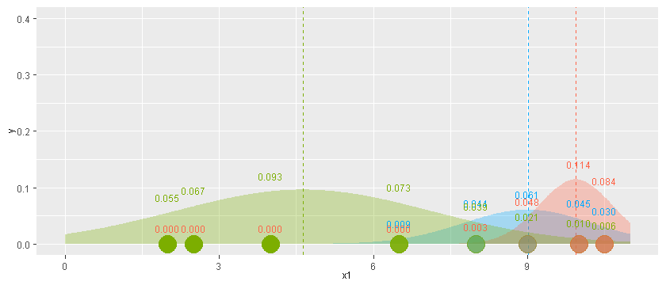

**Iteration 30**

| cluster | size | mean | sd |
| --- | --- | --- | --- |
| A | 0.3946705 | 7.939825 | 1.1287852 |
| B | 0.2308732 | 10.258786 | 0.2498661 |
| C | 0.3744563 | 2.831858 | 0.8498998 |

| x1 | g.A | g.B | g.C | weight.A | weight.B | weight.C |
| --- | --- | --- | --- | --- | --- | --- |
| 2.0 | 0.0000001354266 | 2.164391e-238 | 1.088724e-01 | 0.000001243901 | 1.988005e-237 | 9.999988e-01 |
| 2.5 | 0.0000012629570 | 1.550699e-210 | 1.628682e-01 | 0.000007754414 | 9.521118e-210 | 9.999922e-01 |
| 4.0 | 0.0003156236781 | 2.098289e-137 | 6.834864e-02 | 0.004596622143 | 3.055867e-136 | 9.954034e-01 |
| 6.5 | 0.0618340416290 | 2.670763e-50 | 1.584939e-05 | 0.999743744229 | 4.318137e-49 | 2.562558e-04 |
| 8.0 | 0.1392888351833 | 6.622497e-19 | 1.642322e-09 | 0.999999988209 | 4.754507e-18 | 1.179076e-08 |
| 9.0 | 0.0897389921030 | 1.136095e-06 | 6.420028e-13 | 0.999987340163 | 1.265983e-05 | 7.154021e-12 |
| 10.0 | 0.0263752963333 | 2.156000e-01 | 6.285999e-17 | 0.108999942248 | 8.910001e-01 | 2.597785e-16 |
| 10.5 | 0.0106533736051 | 2.313164e-01 | 3.701071e-19 | 0.044027698474 | 9.559723e-01 | 1.529559e-18 |

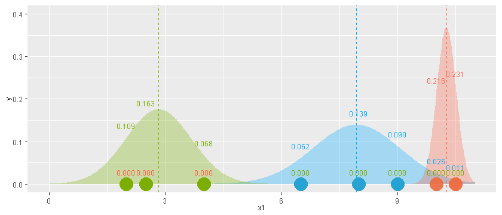

#### Commit Cluster Assignments

| x1 | g.A | g.B | g.C | weight.A | weight.B | weight.C | cluster |
| --- | --- | --- | --- | --- | --- | --- | --- |
| 2.0 | 0.0000001354266 | 2.164391e-238 | 1.088724e-01 | 0.000001243901 | 1.988005e-237 | 9.999988e-01 | C |
| 2.5 | 0.0000012629570 | 1.550699e-210 | 1.628682e-01 | 0.000007754414 | 9.521118e-210 | 9.999922e-01 | C |
| 4.0 | 0.0003156236781 | 2.098289e-137 | 6.834864e-02 | 0.004596622143 | 3.055867e-136 | 9.954034e-01 | C |
| 6.5 | 0.0618340416290 | 2.670763e-50 | 1.584939e-05 | 0.999743744229 | 4.318137e-49 | 2.562558e-04 | A |
| 8.0 | 0.1392888351833 | 6.622497e-19 | 1.642322e-09 | 0.999999988209 | 4.754507e-18 | 1.179076e-08 | A |
| 9.0 | 0.0897389921030 | 1.136095e-06 | 6.420028e-13 | 0.999987340163 | 1.265983e-05 | 7.154021e-12 | A |
| 10.0 | 0.0263752963333 | 2.156000e-01 | 6.285999e-17 | 0.108999942248 | 8.910001e-01 | 2.597785e-16 | B |
| 10.5 | 0.0106533736051 | 2.313164e-01 | 3.701071e-19 | 0.044027698474 | 9.559723e-01 | 1.529559e-18 | B |

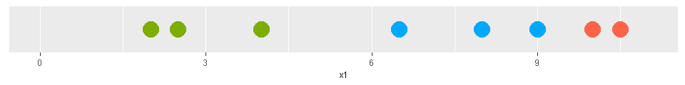

### Example: One Variable, Many Clusters - Initialization II

#### Initialize

**Initialization**

| class | size | mean | sd |
| --- | --- | --- | --- |
| A | 0.3333333 | 1 | 2.0 |
| B | 0.3333333 | 5 | 0.5 |
| C | 0.3333333 | 10 | 0.3 |

| x1 | g.A | g.B | g.C | weight.A | weight.B | weight.C |
| --- | --- | --- | --- | --- | --- | --- |
| 2.0 | 0.0586775544607 | 4.050589e-09 | 1.701578e-155 | 0.999999930969 | 6.903131e-08 | 2.899878e-154 |
| 2.5 | 0.0501895720258 | 9.911463e-07 | 8.504366e-137 | 0.999980252337 | 1.974766e-05 | 1.694415e-135 |
| 4.0 | 0.0215862659443 | 3.599398e-02 | 6.134387e-88 | 0.374890146121 | 6.251099e-01 | 1.065363e-86 |
| 6.5 | 0.0015155937503 | 2.954566e-03 | 1.231729e-30 | 0.339046917304 | 6.609531e-01 | 2.755449e-28 |
| 8.0 | 0.0001454471158 | 4.050589e-09 | 9.901000e-11 | 0.999971470867 | 2.784842e-05 | 6.807091e-07 |
| 9.0 | 0.0000223050376 | 3.368181e-15 | 1.713643e-03 | 0.012848906139 | 1.940254e-12 | 9.871511e-01 |
| 10.0 | 0.0000026639569 | 5.129732e-23 | 4.432692e-01 | 0.000006009758 | 1.157243e-22 | 9.999940e-01 |
| 10.5 | 0.0000008382512 | 1.412546e-27 | 1.105302e-01 | 0.000007583857 | 1.277964e-26 | 9.999924e-01 |

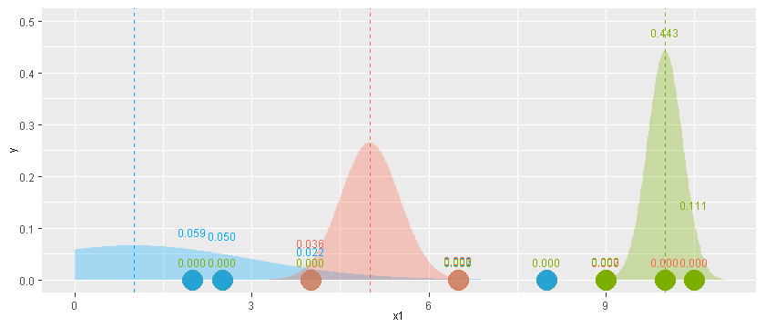

#### Iterate

Use expectation-maximization to iteratively update partial cluster assignments & Guassian functions.

**Iteration 1**

| cluster | size | mean | sd |
| --- | --- | --- | --- |
| A | 0.4658439 | 4.378845 | 2.5459046 |
| B | 0.1607638 | 5.284854 | 1.2496030 |
| C | 0.3733923 | 9.836915 | 0.6225456 |

| x1 | g.A | g.B | g.C | weight.A | weight.B | weight.C |
| --- | --- | --- | --- | --- | --- | --- |
| 2.0 | 0.047176312 | 0.001621080184 | 9.279098e-36 | 0.96677937 | 0.03322063157 | 1.901556e-34 |
| 2.5 | 0.055596116 | 0.004283897006 | 1.653370e-31 | 0.92845865 | 0.07154135006 | 2.761139e-30 |
| 4.0 | 0.072193820 | 0.030252060047 | 1.950278e-20 | 0.70470203 | 0.29529796630 | 1.903716e-19 |
| 6.5 | 0.051590906 | 0.031988168735 | 1.380655e-07 | 0.61726958 | 0.38272876327 | 1.651912e-06 |
| 8.0 | 0.026546382 | 0.004843449263 | 3.078541e-03 | 0.77016641 | 0.14051865344 | 8.931494e-02 |
| 9.0 | 0.014056330 | 0.000617933831 | 9.693097e-02 | 0.12594687 | 0.00553678181 | 8.685163e-01 |
| 10.0 | 0.006378736 | 0.000041553164 | 2.312078e-01 | 0.02684336 | 0.00017486639 | 9.729818e-01 |
| 10.5 | 0.004055454 | 0.000008474972 | 1.356925e-01 | 0.02901802 | 0.00006064103 | 9.709213e-01 |

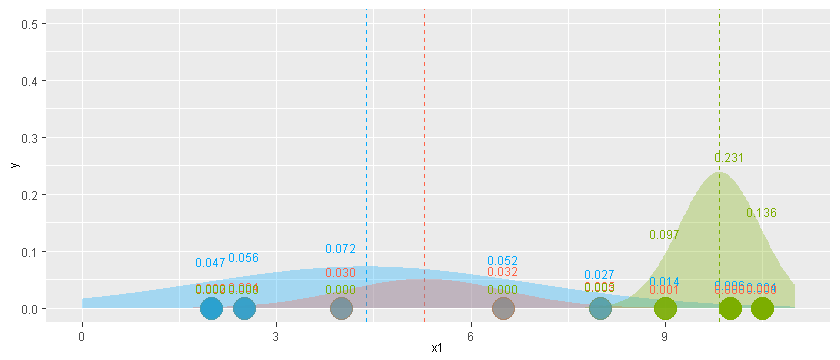

**Iteration 100**

| cluster | size | mean | sd |
| --- | --- | --- | --- |
| A | 0.3744563 | 2.831858 | 0.8498998 |
| B | 0.3946706 | 7.939825 | 1.1287855 |
| C | 0.2308731 | 10.258786 | 0.2498661 |

| x1 | g.A | g.B | g.C | weight.A | weight.B | weight.C |
| --- | --- | --- | --- | --- | --- | --- |
| 2.0 | 1.088724e-01 | 0.0000001354272 | 2.164380e-238 | 9.999988e-01 | 0.000001243906 | 1.987995e-237 |
| 2.5 | 1.628682e-01 | 0.0000012629616 | 1.550692e-210 | 9.999922e-01 | 0.000007754442 | 9.521074e-210 |
| 4.0 | 6.834864e-02 | 0.0003156241931 | 2.098281e-137 | 9.954034e-01 | 0.004596629683 | 3.055857e-136 |
| 6.5 | 1.584939e-05 | 0.0618340398689 | 2.670758e-50 | 2.562558e-04 | 0.999743744241 | 4.318129e-49 |
| 8.0 | 1.642321e-09 | 0.1392888258068 | 6.622490e-19 | 1.179076e-08 | 0.999999988209 | 4.754502e-18 |
| 9.0 | 6.420027e-13 | 0.0897390195272 | 1.136094e-06 | 7.154018e-12 | 0.999987340174 | 1.265982e-05 |
| 10.0 | 6.285997e-17 | 0.0263753226445 | 2.156000e-01 | 2.597785e-16 | 0.109000065624 | 8.909999e-01 |
| 10.5 | 3.701070e-19 | 0.0106533891931 | 2.313164e-01 | 1.529559e-18 | 0.044027765893 | 9.559722e-01 |

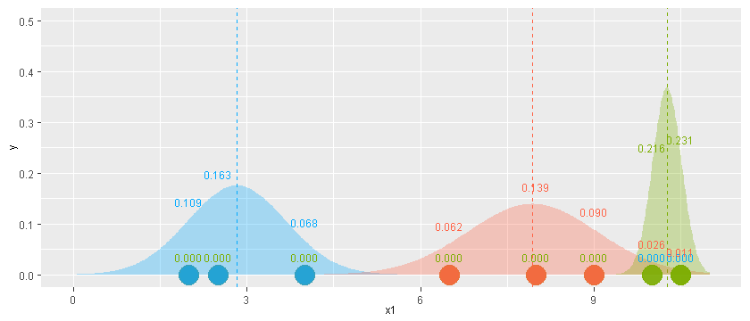

#### Commit Cluster Assignments

| x1 | g.A | g.B | g.C | weight.A | weight.B | weight.C | cluster |
| --- | --- | --- | --- | --- | --- | --- | --- |
| 2.0 | 1.088724e-01 | 0.0000001354272 | 2.164380e-238 | 9.999988e-01 | 0.000001243906 | 1.987995e-237 | A |
| 2.5 | 1.628682e-01 | 0.0000012629616 | 1.550692e-210 | 9.999922e-01 | 0.000007754442 | 9.521074e-210 | A |
| 4.0 | 6.834864e-02 | 0.0003156241931 | 2.098281e-137 | 9.954034e-01 | 0.004596629683 | 3.055857e-136 | A |
| 6.5 | 1.584939e-05 | 0.0618340398689 | 2.670758e-50 | 2.562558e-04 | 0.999743744241 | 4.318129e-49 | B |
| 8.0 | 1.642321e-09 | 0.1392888258068 | 6.622490e-19 | 1.179076e-08 | 0.999999988209 | 4.754502e-18 | B |
| 9.0 | 6.420027e-13 | 0.0897390195272 | 1.136094e-06 | 7.154018e-12 | 0.999987340174 | 1.265982e-05 | B |
| 10.0 | 6.285997e-17 | 0.0263753226445 | 2.156000e-01 | 2.597785e-16 | 0.109000065624 | 8.909999e-01 | C |
| 10.5 | 3.701070e-19 | 0.0106533891931 | 2.313164e-01 | 1.529559e-18 | 0.044027765893 | 9.559722e-01 | C |

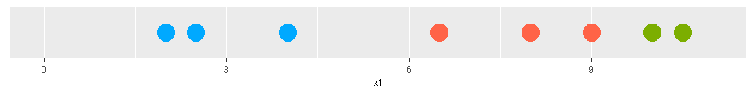

### Example: Two Variables, Two Clusters - Initialization I

#### Data

| x1 | x2 |
| --- | --- |
| 2.0 | 10.0 |
| 2.5 | 6.2 |
| 4.0 | 9.0 |
| 6.5 | 6.0 |
| 8.0 | 1.0 |
| 9.0 | 3.5 |
| 10.0 | 2.0 |
| 10.5 | 7.0 |

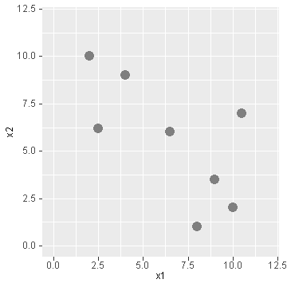

#### Initialize

Each Gaussian function is defined by a size, the mean of each variable, the standard deviation of each variable, and the correlation between variables.

**Initialization**

| cluster | size | mean.x1 | mean.x2 | sd.x1 | sd.x2 | cor |
| --- | --- | --- | --- | --- | --- | --- |
| A | 0.5 | 7 | 2 | 2 | 1 | 0 |
| B | 0.5 | 8 | 2 | 2 | 1 | 0 |

| x1 | x2 | g.A | g.B | weight.A | weight.B |
| --- | --- | --- | --- | --- | --- |
| 2.0 | 10.0 | 2.213943e-17 | 5.597725e-18 | 0.7981868 | 0.2018132 |
| 2.5 | 6.2 | 4.677081e-07 | 1.340006e-07 | 0.7772999 | 0.2227001 |
| 4.0 | 9.0 | 2.957768e-13 | 1.232981e-13 | 0.7057850 | 0.2942150 |
| 6.5 | 6.0 | 1.293697e-05 | 1.007532e-05 | 0.5621765 | 0.4378235 |
| 8.0 | 1.0 | 2.129738e-02 | 2.413309e-02 | 0.4687906 | 0.5312094 |
| 9.0 | 3.5 | 7.834867e-03 | 1.139966e-02 | 0.4073334 | 0.5926666 |
| 10.0 | 2.0 | 1.291751e-02 | 2.413309e-02 | 0.3486451 | 0.6513549 |
| 10.5 | 7.0 | 3.206754e-08 | 6.788699e-08 | 0.3208213 | 0.6791787 |

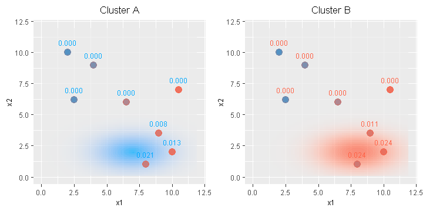

#### Iterate

Use expectation-maximization to iteratively update partial cluster assignments & Guassian functions.

**Iteration 100**

| cluster | size | mean.x1 | mean.x2 | sd.x1 | sd.x2 | cor |
| --- | --- | --- | --- | --- | --- | --- |
| A | 0.5047318 | 3.800659 | 7.754517 | 2.094129 | 2.067838 | -0.5660389 |
| B | 0.4952682 | 9.377114 | 3.379076 | 1.111019 | 2.633836 | 0.7382655 |

| x1 | x2 | g.A | g.B | weight.A | weight.B |
| --- | --- | --- | --- | --- | --- |
| 2.0 | 10.0 | 0.01193891643 | 6.017661e-38 | 1.000000000 | 5.040374e-36 |
| 2.5 | 6.2 | 0.00757712054 | 1.243469e-25 | 1.000000000 | 1.641084e-23 |
| 4.0 | 9.0 | 0.01631863047 | 9.308922e-23 | 1.000000000 | 5.704475e-21 |
| 6.5 | 6.0 | 0.00970339399 | 1.294188e-07 | 0.999986663 | 1.333730e-05 |
| 8.0 | 1.0 | 0.00010653941 | 1.852150e-02 | 0.005719304 | 9.942807e-01 |
| 9.0 | 3.5 | 0.00075471584 | 3.422820e-02 | 0.021573841 | 9.784262e-01 |
| 10.0 | 2.0 | 0.00011416636 | 1.299020e-02 | 0.008712083 | 9.912879e-01 |
| 10.5 | 7.0 | 0.00002896364 | 1.552191e-02 | 0.001862509 | 9.981375e-01 |

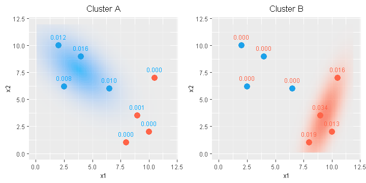

#### Commit Cluster Assignments

| x1 | x2 | g.A | g.B | weight.A | weight.B | cluster |
| --- | --- | --- | --- | --- | --- | --- |
| 2.0 | 10.0 | 0.01193891643 | 6.017661e-38 | 1.000000000 | 5.040374e-36 | A |
| 2.5 | 6.2 | 0.00757712054 | 1.243469e-25 | 1.000000000 | 1.641084e-23 | A |
| 4.0 | 9.0 | 0.01631863047 | 9.308922e-23 | 1.000000000 | 5.704475e-21 | A |
| 6.5 | 6.0 | 0.00970339399 | 1.294188e-07 | 0.999986663 | 1.333730e-05 | A |
| 8.0 | 1.0 | 0.00010653941 | 1.852150e-02 | 0.005719304 | 9.942807e-01 | B |
| 9.0 | 3.5 | 0.00075471584 | 3.422820e-02 | 0.021573841 | 9.784262e-01 | B |
| 10.0 | 2.0 | 0.00011416636 | 1.299020e-02 | 0.008712083 | 9.912879e-01 | B |
| 10.5 | 7.0 | 0.00002896364 | 1.552191e-02 | 0.001862509 | 9.981375e-01 | B |

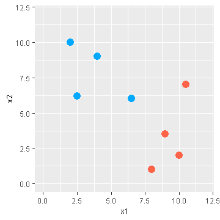

### Example: Two Variables, Two Clusters - Initialization II

#### Data

| x1 | x2 |
| --- | --- |
| 2.0 | 10.0 |
| 2.5 | 6.2 |
| 4.0 | 9.0 |
| 6.5 | 6.0 |
| 8.0 | 1.0 |
| 9.0 | 3.5 |
| 10.0 | 2.0 |
| 10.5 | 7.0 |

#### Initialize

Each Gaussian function is defined by a size, the mean of each variable, the standard deviation of each variable, and the correlation between variables.

**Initialization**

| cluster | size | mean.x1 | mean.x2 | sd.x1 | sd.x2 | cor |
| --- | --- | --- | --- | --- | --- | --- |
| A | 0.5 | 6 | 10 | 4 | 1 | 0 |
| B | 0.5 | 6 | 2 | 1 | 4 | 0 |

| x1 | x2 | g.A | g.B | weight.A | weight.B |
| --- | --- | --- | --- | --- | --- |
| 2.0 | 10.0 | 1.206654e-02 | 0.0000009032029 | 9.999252e-01 | 0.00007484623 |
| 2.5 | 6.2 | 9.928203e-06 | 0.0000250767708 | 2.836226e-01 | 0.71637737117 |
| 4.0 | 9.0 | 1.064869e-02 | 0.0005822744790 | 9.481545e-01 | 0.05184546665 |
| 6.5 | 6.0 | 6.621881e-06 | 0.0106486877744 | 6.214630e-04 | 0.99937853698 |
| 8.0 | 1.0 | 4.523940e-20 | 0.0026095731683 | 1.733594e-17 | 1.00000000000 |
| 9.0 | 3.5 | 1.004879e-11 | 0.0002060006759 | 4.878039e-08 | 0.99999995122 |
| 10.0 | 2.0 | 1.528127e-16 | 0.0000066738169 | 2.289735e-11 | 0.99999999998 |
| 10.5 | 7.0 | 1.173756e-04 | 0.0000003649270 | 9.969006e-01 | 0.00309941552 |

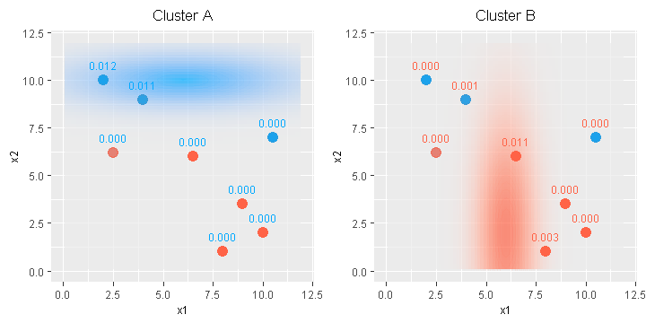

#### Iterate

Use expectation-maximization to iteratively update partial cluster assignments & Guassian functions.

**Iteration 100**

| cluster | size | mean.x1 | mean.x2 | sd.x1 | sd.x2 | cor |
| --- | --- | --- | --- | --- | --- | --- |
| A | 0.3685847 | 5.535810 | 8.655633 | 4.465075 | 1.534684 | -0.9944391 |
| B | 0.6314153 | 7.161824 | 3.796496 | 2.940194 | 2.397248 | -0.7594407 |

| x1 | x2 | g.A | g.B | weight.A | weight.B |
| --- | --- | --- | --- | --- | --- |
| 2.0 | 10.0 | 4.173245e-02 | 0.00073126071 | 9.827792e-01 | 0.017220837 |
| 2.5 | 6.2 | 2.334868e-103 | 0.00594307601 | 3.928720e-101 | 1.000000000 |
| 4.0 | 9.0 | 4.104818e-02 | 0.00140978041 | 9.667958e-01 | 0.033204151 |
| 6.5 | 6.0 | 8.354585e-47 | 0.01102843313 | 7.575496e-45 | 1.000000000 |
| 8.0 | 1.0 | 0.000000e+00 | 0.00724485894 | 0.000000e+00 | 1.000000000 |
| 9.0 | 3.5 | 4.530683e-133 | 0.01558207102 | 2.907626e-131 | 1.000000000 |
| 10.0 | 2.0 | 8.743831e-221 | 0.01374901707 | 6.359604e-219 | 1.000000000 |
| 10.5 | 7.0 | 4.241990e-02 | 0.00003810037 | 9.991026e-01 | 0.000897366 |

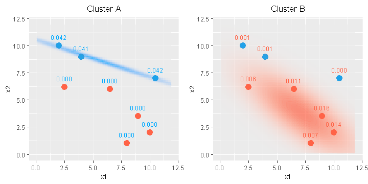

#### Commit Cluster Assignments

| x1 | x2 | g.A | g.B | weight.A | weight.B | cluster |
| --- | --- | --- | --- | --- | --- | --- |
| 2.0 | 10.0 | 4.173245e-02 | 0.00073126071 | 9.827792e-01 | 0.017220837 | A |
| 2.5 | 6.2 | 2.334868e-103 | 0.00594307601 | 3.928720e-101 | 1.000000000 | B |
| 4.0 | 9.0 | 4.104818e-02 | 0.00140978041 | 9.667958e-01 | 0.033204151 | A |
| 6.5 | 6.0 | 8.354585e-47 | 0.01102843313 | 7.575496e-45 | 1.000000000 | B |
| 8.0 | 1.0 | 0.000000e+00 | 0.00724485894 | 0.000000e+00 | 1.000000000 | B |
| 9.0 | 3.5 | 4.530683e-133 | 0.01558207102 | 2.907626e-131 | 1.000000000 | B |
| 10.0 | 2.0 | 8.743831e-221 | 0.01374901707 | 6.359604e-219 | 1.000000000 | B |
| 10.5 | 7.0 | 4.241990e-02 | 0.00003810037 | 9.991026e-01 | 0.000897366 | A |

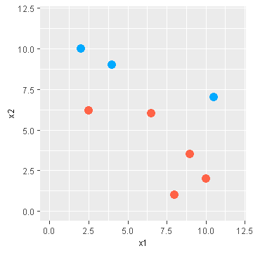

### Example: Two Variables, Two Clusters - Initialization III

#### Data

| x1 | x2 |
| --- | --- |
| 2.0 | 10.0 |
| 2.5 | 6.2 |
| 4.0 | 9.0 |
| 6.5 | 6.0 |
| 8.0 | 1.0 |
| 9.0 | 3.5 |
| 10.0 | 2.0 |
| 10.5 | 7.0 |

#### Initialize

Each Gaussian function is defined by a size, the mean of each variable, the standard deviation of each variable, and the correlation between variables.

**Initialization**

| cluster | size | mean.x1 | mean.x2 | sd.x1 | sd.x2 | cor |
| --- | --- | --- | --- | --- | --- | --- |
| A | 0.5 | 6 | 6 | 3 | 3 | 0 |
| B | 0.5 | 7 | 6 | 3 | 3 | 0 |

| x1 | x2 | g.A | g.B | weight.A | weight.B |
| --- | --- | --- | --- | --- | --- |
| 2.0 | 10.0 | 0.001494406 | 0.0009064029 | 0.6224593 | 0.3775407 |
| 2.5 | 6.2 | 0.004467052 | 0.0028641861 | 0.6093175 | 0.3906825 |
| 4.0 | 9.0 | 0.004294281 | 0.0032527684 | 0.5690013 | 0.4309987 |
| 6.5 | 6.0 | 0.008719985 | 0.0087199854 | 0.5000000 | 0.5000000 |
| 8.0 | 1.0 | 0.001765432 | 0.0020856113 | 0.4584295 | 0.5415705 |
| 9.0 | 3.5 | 0.003789690 | 0.0050031215 | 0.4309987 | 0.5690013 |
| 10.0 | 2.0 | 0.001494406 | 0.0022047576 | 0.4039848 | 0.5960152 |
| 10.5 | 7.0 | 0.002715432 | 0.0042350509 | 0.3906825 | 0.6093175 |

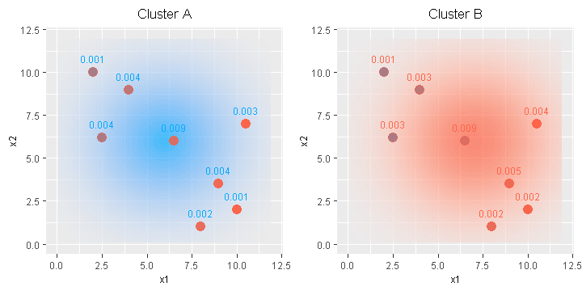

#### Iterate

Use expectation-maximization to iteratively update partial cluster assignments & Guassian functions.

**Iteration 100**

| cluster | size | mean.x1 | mean.x2 | sd.x1 | sd.x2 | cor |
| --- | --- | --- | --- | --- | --- | --- |
| A | 0.6282216 | 5.019762 | 6.622018 | 3.299584 | 3.123661 | -0.8626278 |
| B | 0.3717784 | 9.169378 | 3.839399 | 1.262547 | 3.024035 | 0.9998213 |

| x1 | x2 | g.A | g.B | weight.A | weight.B |
| --- | --- | --- | --- | --- | --- |
| 2.0 | 10.0 | 0.01068037761 | 0.0000000 | 1.0000000000 | 0.0000000 |
| 2.5 | 6.2 | 0.00418150343 | 0.0000000 | 1.0000000000 | 0.0000000 |
| 4.0 | 9.0 | 0.01133405162 | 0.0000000 | 1.0000000000 | 0.0000000 |
| 6.5 | 6.0 | 0.01618627970 | 0.0000000 | 1.0000000000 | 0.0000000 |
| 8.0 | 1.0 | 0.00166547645 | 0.4229448 | 0.0039223646 | 0.9960776 |
| 9.0 | 3.5 | 0.00923395978 | 0.4153433 | 0.0217485964 | 0.9782514 |
| 10.0 | 2.0 | 0.00577185210 | 0.0000000 | 1.0000000000 | 0.0000000 |
| 10.5 | 7.0 | 0.00004315845 | 0.4245564 | 0.0001016451 | 0.9998984 |

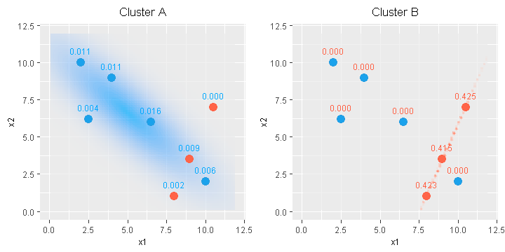

#### Commit Cluster Assignments

| x1 | x2 | g.A | g.B | weight.A | weight.B | cluster |
| --- | --- | --- | --- | --- | --- | --- |
| 2.0 | 10.0 | 0.01068037761 | 0.0000000 | 1.0000000000 | 0.0000000 | A |
| 2.5 | 6.2 | 0.00418150343 | 0.0000000 | 1.0000000000 | 0.0000000 | A |
| 4.0 | 9.0 | 0.01133405162 | 0.0000000 | 1.0000000000 | 0.0000000 | A |
| 6.5 | 6.0 | 0.01618627970 | 0.0000000 | 1.0000000000 | 0.0000000 | A |
| 8.0 | 1.0 | 0.00166547645 | 0.4229448 | 0.0039223646 | 0.9960776 | B |
| 9.0 | 3.5 | 0.00923395978 | 0.4153433 | 0.0217485964 | 0.9782514 | B |
| 10.0 | 2.0 | 0.00577185210 | 0.0000000 | 1.0000000000 | 0.0000000 | A |
| 10.5 | 7.0 | 0.00004315845 | 0.4245564 | 0.0001016451 | 0.9998984 | B |

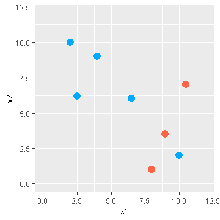